# Cours-Dérivation-Dichotomie-Exemple12

## Import des bibliothèques Python

```python
import numpy as np                #pour disposer des tableaux de type array
import matplotlib.pyplot as plt   #pour les graphiques
```

```python
%matplotlib inline
#pour l'affichage des graphiques dans la page et non pas dans une fenetre pop up
```

```python
import operator                   #pour utiliser les opérateurs de base sous forme de fonctions
```

```python
from sympy import *               #pour le calcul formel
init_printing()
t = symbols('t')
```

```python
def dérivée(exp, t):
    return diff(exp,t)

def simplifier(exp):
    return simplify(exp)

def factoriser(exp):
    return factor(exp)
```

## Résolution approchée de $f(x)=0$ par dichotomie, exemple 12 du cours

Soit $f$ la fonction définie sur $\mathbb{R}$ par $f(x)=40x^3-561x^2+1917x-200$ definie sur $\mathbb{R}$ et dérivable sur $\mathbb{R}$ .

### Question 1 : Calcul de dérivée

```python
#expression de f(x)
fexp = 40 * t**3 - 561*t**2 + 1917 * t - 200
fexp
```

$\displaystyle 40 t^{3} - 561 t^{2} + 1917 t - 200$

```python
#expression de f'(x)
fprimexp = dérivée(fexp, t)
fprimexp
```

$\displaystyle 120 t^{2} - 1122 t + 1917$

```python
factoriser(fprimexp)
```

$\displaystyle 3 \left(4 t - 9\right) \left(10 t - 71\right)$

### Questions 2 et 3 Etude des variations de $f$

```python
f = lambdify(t, fexp,"numpy")
fprim = lambdify(t, fprimexp,"numpy")
```

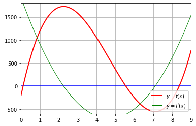

```python
#tracé des  courbes  de f et f'
#Message d'erreur pour f' pour le point d'abscisse 0 (division par 0)
xmin, xmax, ymin, ymax = 0, 9, -600 , 1800
plt.axis([xmin, xmax, ymin, ymax])
tx = np.linspace(xmin, xmax, 1001)
ty = f(tx)
tz = fprim(tx)
plt.axhline(color='blue')
plt.axvline(color='blue')
plt.grid(True)
plt.plot(tx, ty, linestyle='-', linewidth=2, color='red', label=r'$y=f(x)$')
plt.plot(tx, tz, linestyle='-', linewidth=1, color='green', label=r"$y=f'(x)$")
plt.legend(loc='lower right')
```

### Question 4 Existence de solutions de l'équation $f(x)=0$ sur $[8;9]$

- $f:x \mapsto 40x^3-561x^2+1917x-200$ est dérivable donc continue sur $[8;9]$
- $f(8)<0$ et $f(9)>0$
- $f$ est strictement croissante sur $[8;9]$

D'après un corollaire du théorème des valeurs intermédiaires, l'équation $f(x)=0$ possède donc une unique solution $\alpha$ dans l'intervalle $[8;9]$

## Résolution approchée par balayage

```python
def balayage(g, a, b, pas, k):
    """Retourne un intervalle d'amplitude pas encadrant l'unique solution de g(x)= k
    dans l'intervalle [a,b]"""
    if g(a) < k:
        comparaison = lambda u, v : operator.lt(u,v)
    else:
        comparaison = lambda u, v : operator.gt(u,v)
    x = a
    #en-tete du tableau
    print('|{etape:^16}|{t:^12}|{ft:^12}|'.format(etape='Etape', t='t', ft='g(t)'))
    count = 1
    while comparaison(g(x), k):
        print('|{etape:^16}|{t:^12.6f}|{ft:^12.6f}|'.format(etape=count,t=x, ft=g(x)))
        x += pas
        count += 1
    print('|{etape:^16}|{t:^12.6f}|{ft:^12.6f}|'.format(etape=count,t=x, ft=g(x)))
    return x - pas, x
```

```python
balayage(f, 8, 9, 0.1, 0)
```

```
|     Etape      |     t      |    g(t)    |
|       1        |  8.000000  |-288.000000 |
|       2        |  8.100000  |-221.870000 |
|       3        |  8.200000  |-147.520000 |
|       4        |  8.300000  | -64.710000 |
|       5        |  8.400000  | 26.800000  |
```

$\displaystyle \left( 8.299999999999999, \ 8.399999999999999\right)$

```python
balayage(f, 8.3, 8.4, 0.01, 0)
```

```
|     Etape      |     t      |    g(t)    |
|       1        |  8.300000  | -64.710000 |
|       2        |  8.310000  | -55.954460 |
|       3        |  8.320000  | -47.111680 |
|       4        |  8.330000  | -38.181420 |
|       5        |  8.340000  | -29.163440 |
|       6        |  8.350000  | -20.057500 |
|       7        |  8.360000  | -10.863360 |
|       8        |  8.370000  | -1.580780  |
|       9        |  8.380000  |  7.790480  |
```

$\displaystyle \left( 8.37, \ 8.379999999999999\right)$

```python
balayage(f, 8.36, 8.38, 0.001, 0)
```

```
|     Etape      |     t      |    g(t)    |
|       1        |  8.360000  | -10.863360 |
|       2        |  8.361000  | -9.939086  |
|       3        |  8.362000  | -9.013927  |
|       4        |  8.363000  | -8.087883  |
|       5        |  8.364000  | -7.160954  |
|       6        |  8.365000  | -6.233140  |
|       7        |  8.366000  | -5.304440  |
|       8        |  8.367000  | -4.374854  |
|       9        |  8.368000  | -3.444383  |
|       10       |  8.369000  | -2.513025  |
|       11       |  8.370000  | -1.580780  |
|       12       |  8.371000  | -0.647649  |
|       13       |  8.372000  |  0.286370  |
```

$\displaystyle \left( 8.370999999999993, \ 8.371999999999993\right)$

## Résolution approchée par dichotomie

### Fonctions Python

```python
def dicho(f,a,b,e, k):
    """valeur approchée à e près de la solution de f(x)=k
    sur [a,b]. On admet que l'utilisateur saisit des paramètres
    où la dichotomie peut s'appliquer. Construit une figure
    à chaque étape.
    Les valeurs de a et b affichées sont celles en sortie de boucle."""
    etape = 0 #nombre d'étapes
    if f(a) <= f(b):
        #croissant ou du moins passage de - à +
        croissant = True
    else:
        croissant = False
    while b - a > e:
        etape += 1
        #on calcule le milieu du segment [a,b]
        m = (a+b)/2
        #figure
        x = np.linspace(a,b,500)
        y = f(x)
        plt.xlim(a,b)
        if croissant:
            plt.ylim(max(f(a),-50),min(f(b),50))
        else:
            plt.ylim(max(f(b),-50),min(f(a),50))
        plt.plot(x,y,color='red')
        plt.grid(True)
        plt.axhline(k)
        plt.title('a=%.4f et m=%.4f et b=%.4f'%(a,m,b))
        plt.show()
        #fin de la figure
        s = (f(m) - k)*(f(a) - k)
        #si f(m) - k  et f(a) - k sont de meme signe, f(x)=k dans ]m,b[
        if s > 0:
            a = m
        #si f(m) - k  et f(a) - k sont de signes opposés, f(x)=k dans ]a,m]
        else:
            b = m
    return a, b, etape

def dicho_tab(f,a,b,e, k):
    """valeur approchée à e près de la solution de f(x)=k
    sur [a,b]. On admet que l'utilisateur saisit des paramètres
    où la dichotomie peut s'appliquer.
    Ne retourne rien mais remplit un tableau avec les valeurs
    de a, b et m aux differentes etapes.
    Les valeurs de a et b affichées sont celles en sortie de boucle"""
    count = 0 #nombre d'étapes
    if f(a) <= f(b):
        #croissant ou du moins passage de - à +
        croissant = True
    else:
        croissant = False
    #en-tete du tableau
    print('|{etape:^16}|{median:^12}|{test:^10}|{binf:^12}|{bsup:^12}|'.format(etape='Etape',
                                                                     binf='a', bsup='b', median='m',
                                                                     test='Choix ?'))
    #première ligne du tableau
    #remplissage de la ligne du tableau
    print('|{etape:^16}|{median:^12}|{test:^10}|{binf:^12}|{bsup:^12}|'.format(etape='initialisation',
                                                                     binf=a, bsup=b, median=str(None),
                                                                     test=str(None)))
    while b - a > e:
        count += 1
        #on calcule le milieu du segment [a,b]
        m = (a+b)/2
        s = (f(m) - k)*(f(a) - k)
        #si f(m) - k  et f(a) - k sont de meme signe, f(x)=k dans ]m,b[
        if s > 0:
            a = m
        #si f(m) - k  et f(a) - k sont de signes opposés, f(x)=k dans ]a,m]
        else:
            b = m
        #remplissage de la ligne du tableau
        print('|{etape:^16}|{median:^12}|{test:^10}|{binf:^12}|{bsup:^12}|'.format(etape=count,
                                                                     binf=a, bsup=b, median=m,
                                                                     test= 'gauche' if b == m else 'droite'))
```

## Résolution par dichotomie de l'équation $f(x)=0$ dans l'intervalle $[8;9]$

### D'abord on s'arrete lorsque l'amplitude de l'intervalle $[a,b]$ est inférieure ou égale à $0,02$

```python
dicho_tab(f, 8, 9, 0.02, 0)
```

```
|     Etape      |     m      | Choix ?  |     a      |     b      |
| initialisation |    None    |   None   |     8      |     9      |
|       1        |    8.5     |  gauche  |     8      |    8.5     |
|       2        |    8.25    |  droite  |    8.25    |    8.5     |
|       3        |   8.375    |  gauche  |    8.25    |   8.375    |
|       4        |   8.3125   |  droite  |   8.3125   |   8.375    |
|       5        |  8.34375   |  droite  |  8.34375   |   8.375    |
|       6        |  8.359375  |  droite  |  8.359375  |   8.375    |
```

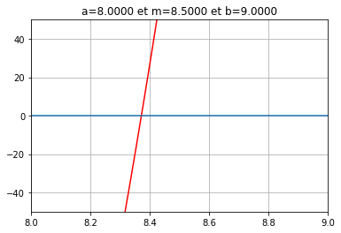

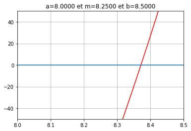

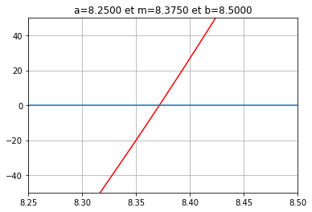

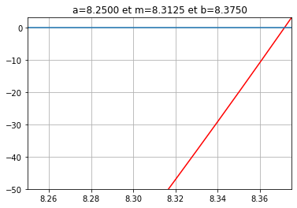

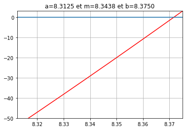

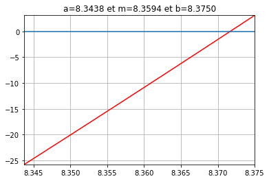

$\displaystyle \left( 8.359375, \ 8.375, \ 6\right)$

```python
dicho(f, 8, 9, 0.02, 0)
```

### Ensuite on s'arrete lorsque l'amplitude de l'intervalle $[a,b]$ est inférieure ou égale à $0,002$

```python
dicho_tab(f, 8, 9, 0.002, 0)
```

```
|     Etape      |     m      | Choix ?  |     a      |     b      |
| initialisation |    None    |   None   |     8      |     9      |
|       1        |    8.5     |  gauche  |     8      |    8.5     |
|       2        |    8.25    |  droite  |    8.25    |    8.5     |
|       3        |   8.375    |  gauche  |    8.25    |   8.375    |
|       4        |   8.3125   |  droite  |   8.3125   |   8.375    |
|       5        |  8.34375   |  droite  |  8.34375   |   8.375    |
|       6        |  8.359375  |  droite  |  8.359375  |   8.375    |
|       7        | 8.3671875  |  droite  | 8.3671875  |   8.375    |
|       8        | 8.37109375 |  droite  | 8.37109375 |   8.375    |
|       9        |8.373046875 |  gauche  | 8.37109375 |8.373046875 |
```

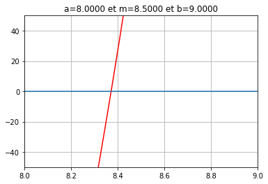

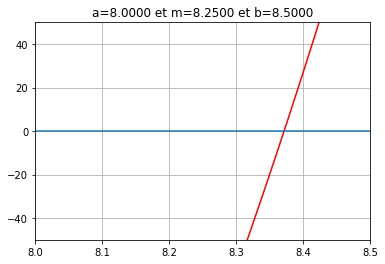

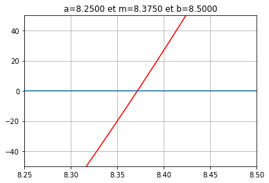

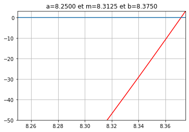

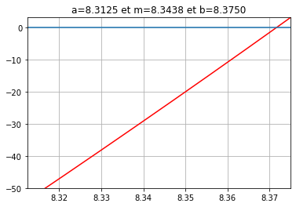

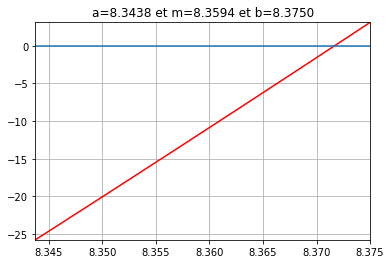

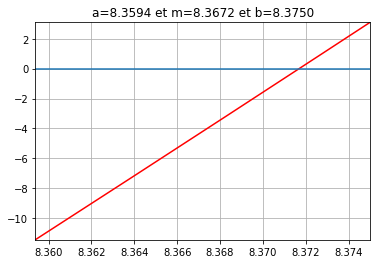

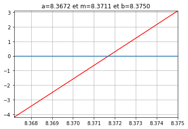

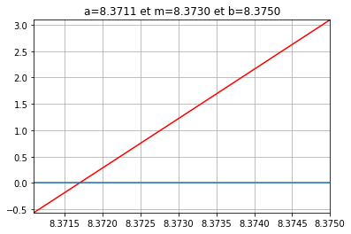

$\displaystyle \left( 8.37109375, \ 8.373046875, \ 9\right)$

```python
dicho(f, 8, 9, 0.002, 0)
```

```python
n = 0
while 1/2**n > 0.001:
    n += 1
print(n)
```

```
10
```

## Exercice 3 TVI et dichotomie fiche d'exercices 2018

```python
dicho_tab(lambda x : 2 * x ** 3 + 6 * x ** 2 - 1, 0, 0.5, 0.01, 0)
```

```
|     Etape      |     m      | Choix ?  |     a      |     b      |
| initialisation |    None    |   None   |     0      |    0.5     |
|       1        |    0.25    |  droite  |    0.25    |    0.5     |
|       2        |   0.375    |  droite  |   0.375    |    0.5     |
|       3        |   0.4375   |  gauche  |   0.375    |   0.4375   |
|       4        |  0.40625   |  gauche  |   0.375    |  0.40625   |
|       5        |  0.390625  |  gauche  |   0.375    |  0.390625  |
|       6        | 0.3828125  |  droite  | 0.3828125  |  0.390625  |
```

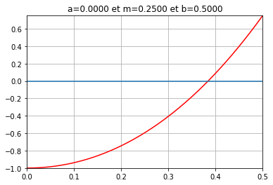

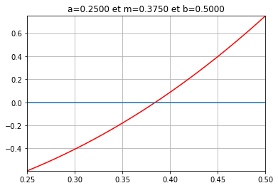

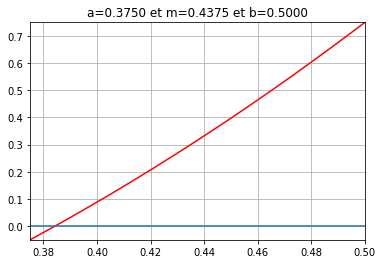

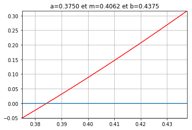

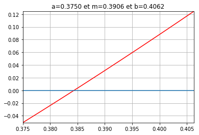

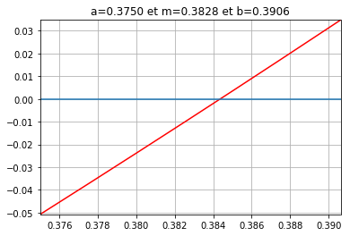

$$\left ( 0.3828125, \quad 0.390625, \quad 6\right )$$

```python
dicho(lambda x : 2 * x ** 3 + 6 * x ** 2 - 1, 0, 0.5, 0.01, 0)
```